# BeerData

Atsu Atakpa

June 27, 2017

## Analysis information for Breweries and Beers

The information provided in this document is an analysis of Beers and Breweries dataset to gain insight into the data. To provide information contained in the data we will apply some statistical methods of analyzing data and provide some visual evidence to support the analysis. The data is imported into R for both the Beers and Breweries and we used a merge to combine both datasets.

```r
# Code to import the Beers and Breweries dataset
library(readxl)
Beers <- read_excel("~//SMU//Doing DataScience//Case Study 1//CaseStudy1//Data//Beers.xlsx")
Breweries <- read_excel("~//SMU/Doing DataScience//Case Study 1//CaseStudy1//Data//Breweries.xlsx")
# merges the Beers and Breweries Data
BB_Data <- merge(Breweries, Beers, by = c("Brewery_id"), all =TRUE)
```

## Number of Breweries in each state

We first want to find the number of Breweries by state. We will run a count on the dataset Breweries. This will give us an idea as to the how the results provided will differ or be similar state by state.

```r
library(plyr)
count(Breweries, "State")
```

```
##    State freq
## 1     AK    7
## 2     AL    3
## 3     AR    2
## 4     AZ   11
## 5     CA   39
## 6     CO   47
## 7     CT    8
## 8     DC    1
## 9     DE    2
## 10    FL   15
## 11    GA    7
## 12    HI    4
## 13    IA    5
## 14    ID    5
```

[output cut: 37 more lines]

## First 6 Observations of Merged Data

To test that the merge of our Beers and Breweries dataset was properly done, we will check the results of the first six data in the dataset BB_Data

```r
head(BB_Data,6)
```

```
##   Brewery_id            Name.x        City State        Name.y Beer_ID
## 1          1 NorthGate Brewing Minneapolis    MN       Pumpion    2689
## 2          1 NorthGate Brewing Minneapolis    MN    Stronghold    2688
## 3          1 NorthGate Brewing Minneapolis    MN   Parapet ESB    2687
## 4          1 NorthGate Brewing Minneapolis    MN  Get Together    2692
## 5          1 NorthGate Brewing Minneapolis    MN Maggie's Leap    2691
## 6          1 NorthGate Brewing Minneapolis    MN    Wall's End    2690
##     ABV IBU                               Style Ounces
## 1 0.060  38                         Pumpkin Ale     16
## 2 0.060  25                     American Porter     16
## 3 0.056  47 Extra Special / Strong Bitter (ESB)     16
## 4 0.045  50                        American IPA     16
## 5 0.049  26                  Milk / Sweet Stout     16
## 6 0.048  19                   English Brown Ale     16
```

## Last 6 Observations of Merged Data

We will also print out the last six results from the merge to confirm that our data merged well.

```r
tail(BB_Data,6)
```

```
##      Brewery_id                        Name.x          City State
## 2405        556         Ukiah Brewing Company         Ukiah    CA
## 2406        557       Butternuts Beer and Ale Garrattsville    NY
## 2407        557       Butternuts Beer and Ale Garrattsville    NY
## 2408        557       Butternuts Beer and Ale Garrattsville    NY
## 2409        557       Butternuts Beer and Ale Garrattsville    NY
## 2410        558 Sleeping Lady Brewing Company     Anchorage    AK
##                         Name.y Beer_ID   ABV IBU                   Style
## 2405             Pilsner Ukiah      98 0.055  NA         German Pilsener
## 2406         Porkslap Pale Ale      49 0.043  NA American Pale Ale (APA)
## 2407           Snapperhead IPA      51 0.068  NA            American IPA
## 2408         Moo Thunder Stout      50 0.049  NA      Milk / Sweet Stout
## 2409  Heinnieweisse Weissebier      52 0.049  NA              Hefeweizen
## 2410 Urban Wilderness Pale Ale      30 0.049  NA        English Pale Ale
##      Ounces
## 2405     12
## 2406     12
## 2407     12
## 2408     12
## 2409     12
## 2410     12
```

## Count of NA’s in each column

The result below will tell us how many missing records for each column that we will be working with.

```r
sapply(BB_Data,function(x) sum(is.na(x)))
```

```
## Brewery_id     Name.x       City      State     Name.y    Beer_ID
##          0          0          0          0          0          0
##        ABV        IBU      Style     Ounces
##         62       1005          5          0
```

## Median ABV and IBU by state

For each state the table below shows the calculation of the median results for ABV and IBU

```r
aggregate(BB_Data[, 7:8],list(BB_Data$State), median, na.rm = TRUE)
```

```
##    Group.1    ABV  IBU
## 1       AK 0.0560 46.0
## 2       AL 0.0600 43.0
## 3       AR 0.0520 39.0
## 4       AZ 0.0550 20.5
## 5       CA 0.0580 42.0
## 6       CO 0.0605 40.0
## 7       CT 0.0600 29.0
## 8       DC 0.0625 47.5
## 9       DE 0.0550 52.0
## 10      FL 0.0570 55.0
## 11      GA 0.0550 55.0
## 12      HI 0.0540 22.5
## 13      IA 0.0555 26.0
## 14      ID 0.0565 39.0
```

[output cut: 37 more lines]

## Plot (needs work)

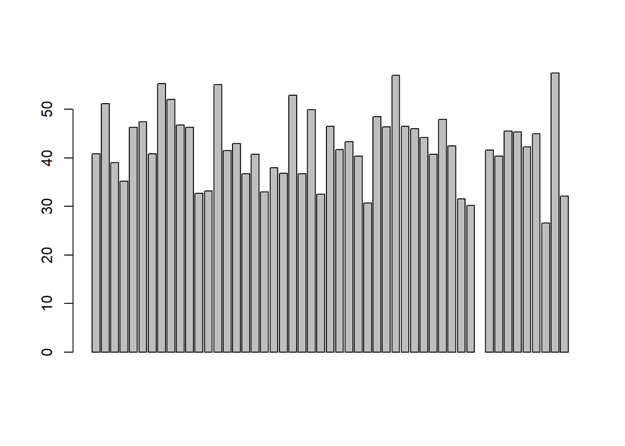

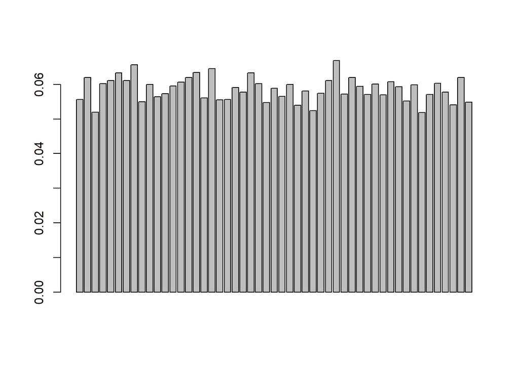

## State with the maximum alcoholic beverage

To find the state with the maximum alcoholic beverage we will run the code below to give us the maximum value in the ABV Colum of the BB_Dataset and return the result by state

```r
attach(BB_Data)
BB_Data[which(BB_Data$ABV == max(BB_Data$ABV, na.rm = TRUE)) ,"State"]
```

```
## [1] "CO"
```

## State with the most bitter beer

To find the state with the most bitter beer, we will run the code below to give us the maximum value in the IBU column of the BB_Dataset and return the result by state

```r
attach(BB_Data)
BB_Data[which(BB_Data$IBU == max(BB_Data$IBU, na.rm = TRUE)) ,"State"]
```

```
## [1] "OR"
```

## Summary statistics of ABV

The summary statistic of the alcohol by volume is provided below with a 5 number summary and number of missing values.

```r
summary(BB_Data$ABV)
```

```
##    Min. 1st Qu.  Median    Mean 3rd Qu.    Max.    NA's
## 0.00100 0.05000 0.05600 0.05977 0.06700 0.12800      62
```

## Plot of ABV and IBU

Determination of relationship between two dataset is enhanced using some visual evidence. We will use a scatter plot to give us a visual perspective.

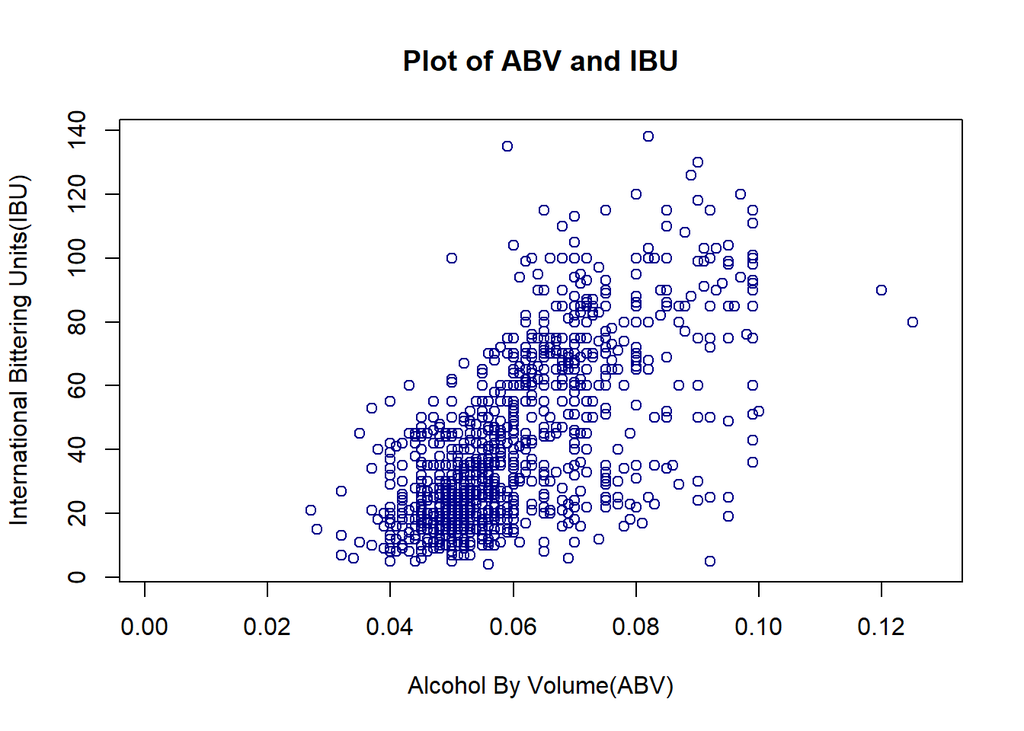

```r
plot(BB_Data$ABV, BB_Data$IBU, main = 'Plot of ABV and IBU',xlab = 'Alcohol By Volume(ABV)', ylab = 'International Bittering Units(IBU)', col = "dark blue",lwd = 1)

library(ggplot2)
```

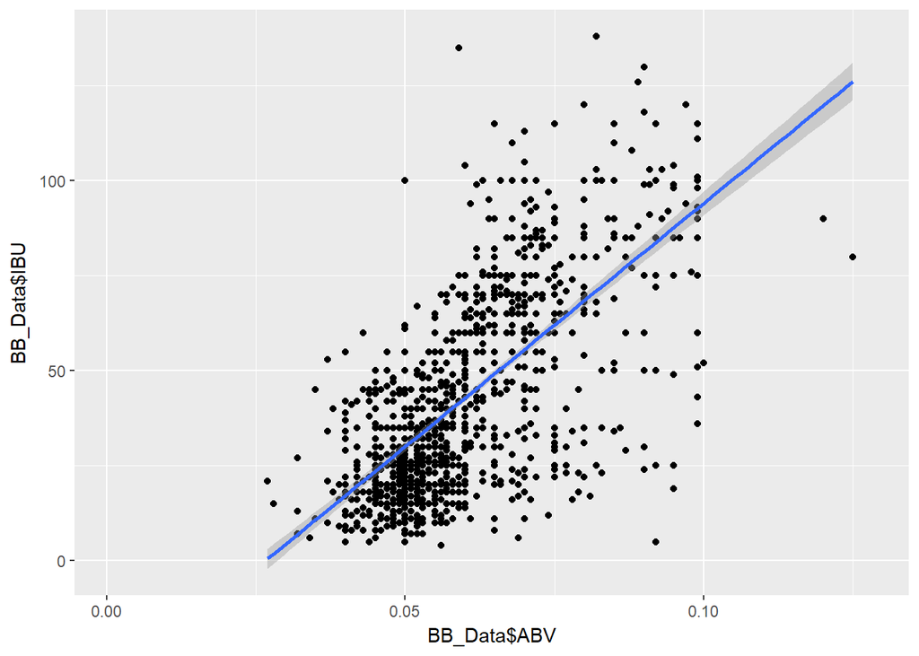

```r
g <- ggplot(BB_Data, aes(x = BB_Data$ABV, y = BB_Data$IBU), na.rm=TRUE) + geom_point() + geom_smooth(method="lm")  # set se=FALSE to turnoff confidence bands
plot(g)
```